# Analyse catégorielle et factorielle des tweets dans le cadre du #deconfinement

Ce projet est fait par : KOUIDER Amira (MLDS 21904040) RADOUANI Nadia (MLDS 21911973) BOUDJEMAI Mohamed (MLDS 21912904)

Extraction des tweets

```r
#chargement des librairies
library(twitteR)
library(stringr)
library(ggplot2)
library(tidyverse)
library(cluster)
library(factoextra)
library(ggplot2)
library(gridExtra)
library(tidyverse)
library(cluster)
library(devtools)
library(stats)
library(JLutils)
library(FactoMineR)
library(factoextra)
library(gplots)
library(NMF)
```

```r
#clés pour la connexion
consumer_key <- "x9XKT0nXXmE84LT9eoBAQleE9"
consumer_secret <- "YAjWKwWrtUtJYSoFLiuy3VUCayP8c9axrpejWhN2X6BtT3JhYr"
access_token <- "809660268-ofBigwBC9vSkplPclbFyG6tZE9nsAD2oWjqXk1AU"
access_secret <- "g6ltImQG082K0mMpvB3WBhlbGXb3TeBc4Kh2NFiR4SIvU"
#Créer une connexion avec Twitter
setup_twitter_oauth(consumer_key, consumer_secret, access_token, access_secret)
```

```r
#récupération des tweets
tweets <- searchTwitter("#deconfinement",n=2000,lang="fr")
```

```r
#affichage d'un tweet en utilisant un index
print(tweets[[1]])
```

```
[1] "Zazie21122977: RT @PaulCassia1: Le @Conseil_Etat a admis la nécessité et la légitimité de la surveillance du #déconfinement par #drone de @prefpolice. Pou…"
```

```r
print(tweets[[2000]])
```

```
[1] "ccidudoubs: RT @ccifrance: Ensemble, soutenons nos commerçants ! Le réseau #CCI lance une campagne de #communication nationale pour soutenir les #comme…"
```

Stockage des tweets dans une structure data.frame

```r
#copier la liste dans une structure data.frame
data <- twListToDF(tweets)

#sauvegarde de la structure data.frame
write.table(data,"tweets.txt",sep="\t",quote=F)

#Sauvegarder en fichier csv
write.csv ( data,"C:/Users/NADIA/Desktop/M1 MLSD/S2/DATA SCIENCE/PROJET/TwitterTweets.csv" )

#dimensions
print(dim(data))
```

```
[1] 2000   16
```

```r
#data <- read.csv("C:/Users/NADIA/Desktop/M1 MLSD/S2/DATA SCIENCE/PROJET/TwitterTweets.csv")
```

```r
#les variables de la base
print(colnames(data))
```

```
 [1] "text"          "favorited"     "favoriteCount" "replyToSN"     "created"
 [6] "truncated"     "replyToSID"    "id"            "replyToUID"    "statusSource"
[11] "screenName"    "retweetCount"  "isRetweet"     "retweeted"     "longitude"
[16] "latitude"
```

```r
#aperçu de la base
print(data[1:10,c('created','screenName','isRetweet','retweeted','retweetCount')])
```

|  | created | screenName | isRetweet | retweeted | retweetCount |
| --- | --- | --- | --- | --- | --- |
| 1 | 2020-05-20 13:21:44 | Zazie21122977 | TRUE | FALSE | 30 |
| 2 | 2020-05-20 13:21:33 | Beckerjean | FALSE | FALSE | 0 |
| 3 | 2020-05-20 13:21:33 | Jojolamojo | FALSE | FALSE | 0 |
| 4 | 2020-05-20 13:21:32 | 3478Susanna | TRUE | FALSE | 3 |
| 5 | 2020-05-20 13:21:23 | jfmam02 | FALSE | FALSE | 0 |
| 6 | 2020-05-20 13:21:21 | JEDUMESNIL | TRUE | FALSE | 7 |
| 7 | 2020-05-20 13:21:18 | HibiscusRose4 | FALSE | FALSE | 0 |
| 8 | 2020-05-20 13:21:04 | AiphanMarcel | FALSE | FALSE | 0 |
| 9 | 2020-05-20 13:20:58 | fabrice911 | TRUE | FALSE | 14 |
| 10 | 2020-05-20 13:20:56 | laprovence | FALSE | FALSE | 0 |

Analyse descriptive:

```r
#comptage du nombre de message par auteurs
comptage <- table(data$screenName)
#tri décroissant
comptage <- sort(comptage,decreasing=TRUE)
#affichage des 10 premiers
print(comptage[1:10])
```

```
         4Tchat   DejoieYannick  Covid19_photos          Firps_      AulnayBoul
             13               7               6               6               5
EnsembleEMacron    lindependant  SeydouTraoreLH  DanielPilotte2  JulietteEtVous
              5               5               5               4               4
```

```r
print(length(unique(data$screenName)))
```

```
[1] 1766
```

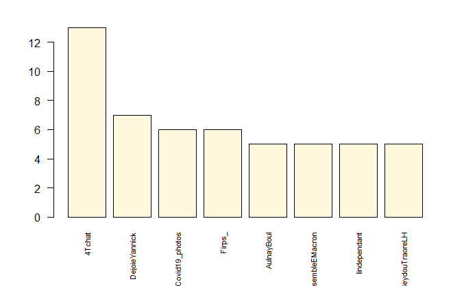

```r
#Nous pouvons représenter graphiquement la liste des auteurs ayant envoyé 5 messages ou plus.
#nous utilisons la variable comptage définie précédemment
barplot(comptage [comptage >= 5], las = 2,cex.names=0.7,col="cornsilk")
```

```r
#liste des messages originaux
id_originaux <- which(!data$isRetweet)
#nombre de messages originaux
print(length(id_originaux))
```

```
[1] 575
```

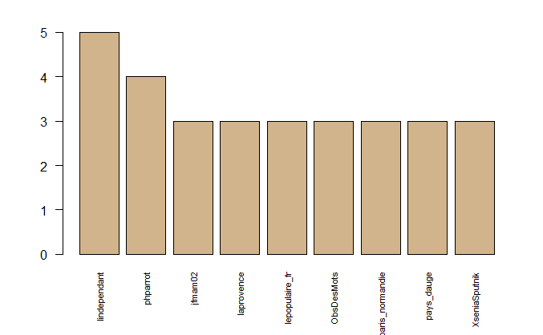

```r
#comptage du nombre de message par auteurs
comptage_bis <- table(data$screenName[id_originaux])
#tri décroissant
comptage_bis <- sort(comptage_bis,decreasing=TRUE)
#graphique de ceux qui ont plus de 3 (inclus) messages
barplot(comptage_bis [comptage_bis >= 3], las = 2,cex.names=0.7, col = "tan")
```

```r
#numéro des messages qui sont des retweets
idRetweets <- which(data$isRetweet)
#vecteur du compteur de retweet
#pour les messages retweetés
nombre_retweets <- data$retweetCount[idRetweets]
#index de tri décroissant selon le nombre
index <- order(nombre_retweets,decreasing=TRUE)
#2 premiers messages avec des auteurs et des identifiants différents
print(data[data$isRetweet,][index[1:2],c('screenName','id','retweetCount')])
```

|  | screenName | id | retweetCount |
| --- | --- | --- | --- |
| 884 | JCenille | 1263066018076864512 | 7397 |
| 1532 | bourguignonmari | 1263045801674244096 | 7397 |

```r
#mais qui correspondent au même texte
print(data[data$isRetweet,][index[1:2],c('text')])
```

```
[1] "RT @padamecour: J’ai pas pu m’empêcher \U0001f605 #Deconfinement https://t.co/I9wytTNnnA"
[2] "RT @padamecour: J’ai pas pu m’empêcher \U0001f605 #Deconfinement https://t.co/I9wytTNnnA"
```

```r
#récupération du data.frame trié selon le nombre de retweets
#on ne travaille que sur les retweets (df$isRetweet)
dfRetweet <- data[data$isRetweet,][index,]

#première occurrence de chaque exemplaire de tweet
first <- !duplicated(dfRetweet$text)

#affichage des $2$ premiers éléments
print(dfRetweet$text[first][1:2])
```

```
[1] "RT @padamecour: J’ai pas pu m’empêcher \U0001f605 #Deconfinement https://t.co/I9wytTNnnA"
[2] "RT @Pabloneruda54: \U0001f534\U0001f4a5 Énorme \U0001f534#Belgique\n\U0001f534Aujourd hui, la haie du déshonneur pour la première ministre belge Sophie Wilmes ( à l'#hôpital St…"
```

```r
#affichage de leur nombre de répétition
print(dfRetweet$retweetCount[first][1:2])
```

```
[1] 7397 2488
```

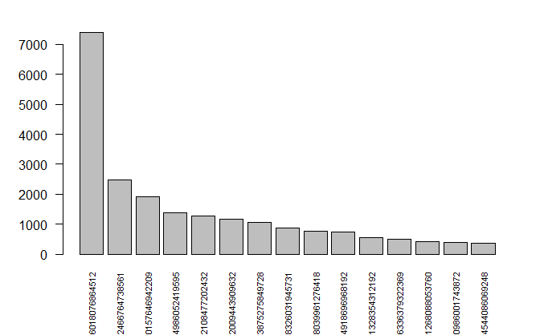

```r
#data.frame correspondant aux premières occurrences
dfFirst <- dfRetweet[first,]

#graphique du nombre de retweets des messages les plus populaires
barplot(dfFirst$retweetCount[1:15], names.arg= dfFirst$id[1:15],las = 2,cex.names=0.7)
```

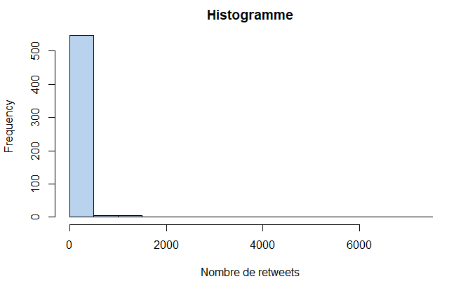

```r
# afficher l'histogramme des fréquences du nombre de retweets.
hist(dfFirst$retweetCount,main="Histogramme",col="slategray2",xlab="Nombre de retweets")
```

Analyse des thèmes et des individus

Dans cette partie nous allons anlayser les thèmes à travers les # et les individus à travers les @ apparaissant dans les messages, mais dans un premier temps il faut faire un nettoyage des tweets qui passe par plusieurs étpes:

Etap 01: Elimination des doublons

```r
#data.frame avec les messages uniques
data2 <- data[!duplicated(data$text),]
#nombre de tweets concernés
print(nrow(data2))
```

```
[1] 1134
```

Nous avons obtenu une base de 1134 messages uniques que nous allons stoquer dans un vecteur

```r
#vecteur avec les messages uniques
mvecteur <- data2$text
#taille du vecteur
print(length(mvecteur))
```

```
[1] 1134
```

```r
#affichage de l'un des messages
print(mvecteur[18])
```

```
[1] "Idem pour la pratique de jeux ou de sports collectifs #Déconfinement #Plages #LaRéunion https://t.co/XdKD3Khkmm"
```

Etape 02: premier cleaning

```r
#suppression du saut de ligne \n
mvectClean <- gsub("\n"," ",mvecteur)

#suppression des URL
mvectClean <- gsub('http\\S+\\s*',"",mvectClean)

#suppression des espaces en trop
mvectClean <- gsub("\\s+"," ",mvectClean)

#suppression des "\"
mvectClean <- gsub("[\\]","",mvectClean)

#suppression des espaces en fin de texte
mvectClean <- gsub("\\s*$","",mvectClean)

#tout mettre en minuscule
mvectClean <- tolower(mvectClean)

#retrait de l'indicateur de retweet
mvectClean <- gsub("rt ","",mvectClean)

#retrait de &amp
mvectClean <- gsub("&amp", "", mvectClean)

#retrait des accents
mvectClean <- gsub("[àâ]","a",mvectClean)
mvectClean <- gsub("[éèê]","e",mvectClean)
mvectClean <- gsub("[ùû]","u",mvectClean)
mvectClean <- gsub("[ç]","c",mvectClean)
mvectClean <- gsub("[ô]","o",mvectClean)
mvectClean <- gsub("[î]","i",mvectClean)

#vérification avec le document n°18
print(mvectClean[18])
```

```
[1] "idem pour la pratique de jeux ou de sports collectifs #deconfinement #plages #lareunion"
```

Après ce premier nettoyage, nous remarquons que certains messages ne diffèrent que par l’URL qu’ils contenaient. Du fait, il se peut qu’on ait encore des dublons, que nous devons supprimer.

```r
#enlever les doublons
mvectClean <- mvectClean[!duplicated(mvectClean)]

#nombre de messages
print(length(mvectClean))
```

```
[1] 1077
```

Nous avons passé de 1134 messages à 1077, donc ça confirme que nous avions vraiment des doublons qu’il a fallu supprimer.

analyse des thèmes

Il s’agit de l’analyse des hashtag, nous allons donc les selectionner et les stocker dans uen vecteur, un mot est un hashtag s’il debute par #.

```r
#les mots délimtés par des ESPACE
mots <- unlist(strsplit(mvectClean," "))

#détecter les hashtag parmi les mots recupérés
hashtag <- regexpr("^#[[:alnum:]_]*",mots)

#récupérer les hashtag
themes <- regmatches(mots,hashtag)

#nombre de hashtags collectés
print(length(themes))
```

```
[1] 1842
```

analysons maintenant les hashtags collectés et commençons par afficher les 15 hashtags les plus populaires

```r
#fréquence d'apparition des hashtags
hashtagNB <- table(themes)

#tri selon la fréquence décroissante
sorthashtagNB <- sort(hashtagNB,decreasing=TRUE)

#affichage des 15 hastags les plus populaires
print(sorthashtagNB[1:15])
```

```
themes
      #deconfinement             #covid19         #coronavirus             #masques
                 584                   71                   44                   29
        #confinement               #covid            #covid_19 #deconfinementjour10
                  27                   27                   24                   16
             #macron              #france              #plages                #velo
                  13                   12                   12                   10
              #paris     #gestesbarrieres            #bretagne
                   9                    8                    7
```

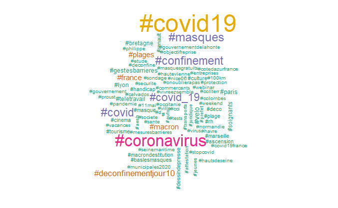

```r
#install.packages("RColorBrewer")
#chargement de la librairie
library(wordcloud)
#affichage
wordcloud(names(sorthashtagNB)[-1],sorthashtagNB[-1],scale=c(3,.5),colors=brewer.pal(6, "Dark2"))
```

le deuxième thème le plus fréquent est “covid19” et c’est tout à fait évident car le thème principal que nous sommes en train d’étudier est le déconfinement.

Analyse des individus

les individus apparaissent dans les messages retweetés, ou quand ils sont cités nommément, ils sont repérés par un @.

```r
#détecter les individus parmi les mots recupérés précédemment
individu <- regexpr("^@[[:alnum:]_]*",mots)

#récupérer l'ensemble des individus
listeIndividus <- regmatches(mots,individu)

#nombre des individus
print(length(listeIndividus))
```

```
[1] 920
```

Nous pouvons repéré les noms d’auteurs apparaissant le plus fréquement dans les messages.

```r
#nombre d'apparition des individus
individusNB <- table(listeIndividus)

#tri selon la fréquence décroissante
sortIndividusNB <- sort(individusNB,decreasing=TRUE)

#affichage des 15 auteurs les plus fréquents
print(sortIndividusNB[1:15])
```

```
listeIndividus
    @conflits_fr  @covid19_photos  @f3htenormandie       @grandlyon    @amisdeproust
              11                5                5                5                4
@guillaumezagury    @olivierveran    @prefet75_idf       @premarmed   @routeplussure
               4                4                4                4                4
               @  @aeviledefrance           @afpfr        @anniv_or      @aulnayboul
               3                3                3                3                3
```

Analyse catégorielle: k-means

Pour pouvoir effectuer cet analyse nous devons construire une matrice documents-termes, ceci passe par plusieurs étapes de cleaning que nous avons commencé précédement, afin de garder uniquemnt les terms qui donnent un sens au message et construire un dictionnaire de mots pertinents.

Continuons avec les cleaning

```r
#retrait des pseudos
mvectClean2 <- gsub("@[[:alnum:]_]*( |:|$)","",mvectClean)

#supprimer les mots liés aux retweets
mvectClean2 = str_replace_all(mvectClean2, "(RT|via)((?:\\b\\W*@\\w+)+)", " ")

#supprimer les caractères particuliers
 ## retour chariot
mvectClean2 = str_replace_all(mvectClean2,"\r", " ")
 ## émoticônes
mvectClean2 = sapply(mvectClean2,function(x) iconv(x, "latin1", "ASCII", sub=""))
 ## la ponctuation
mvectClean2 = str_replace_all(mvectClean2, "[[:punct:]]", " ")
 ## les nombres
mvectClean2 = str_replace_all(mvectClean2, "[[:digit:]]", " ")

 ## les lien HTML
mvectClean2 = str_replace_all(mvectClean2,"https.*", " ")

# les espaces inutiles
 ## plus de deux espaces dans le tweet
mvectClean2 = str_replace_all(mvectClean2, "[\t]{2,}", " ")
 ## espaces de début de tweet
mvectClean2 = str_trim(mvectClean2)

#vérification avec le document n°15
print(mvectClean2[18])
```

```
[1] "idem pour la pratique de jeux ou de sports collectifs  deconfinement  plages  lareunion"
```

Transformation du vecteur de tweets en un format “Corpus”

```r
#importation de la libraire
library(NLP)
library(tm)

#transformation de la liste des tweets en un format interne
docs <- Corpus(VectorSource(mvectClean2))
#docs <- iconv(x = docs,"latin1","ASCII",sub = "")
print(docs)
```

```
<<SimpleCorpus>>
Metadata:  corpus specific: 1, document level (indexed): 0
Content:  documents: 1077
```

Une dernière étape du cleaning sera effectuée sur le corpus

```r
#retrait des ponctuations
docs <- tm_map(docs,removePunctuation)
```

```
transformation drops documents
```

```r
#retrait des nombres
docs <- tm_map(docs,removeNumbers)
```

```
transformation drops documents
```

```r
#retrait des stopwords (mots outils)
docs <- tm_map(docs,removeWords,stopwords("french"))
```

```
transformation drops documents
```

```r
#retirer les espaces en trop
docs <- tm_map(docs,stripWhitespace)
```

```
transformation drops documents
```

```r
#vérification avec le document n°18
print(docs[[18]]$content)
```

```
[1] "idem pratique jeux sports collectifs deconfinement plages lareunion"
```

Création de la matrice documents-termes

```r
#création de la MDT à partir du corpus
docTerms <- DocumentTermMatrix(docs,control=list(weighting=weightBin))
print(docTerms)
```

```
<<DocumentTermMatrix (documents: 1077, terms: 3697)>>
Non-/sparse entries: 9708/3971961
Sparsity           : 100%
Maximal term length: 29
Weighting          : binary (bin)
```

Vérification des mots

```r
#termes apparaissant au moins 40 fois
print(findFreqTerms(docTerms,40))
```

```
 [1] "deconfinement" "plus"          "covid"         "coronavirus"   "reprise"
 [6] "confinement"   "apres"         "masques"       "france"        "depuis"
[11] "mai"
```

Visualisons maintenant les mots les plus fréquents par un plot, avant de faire celà et afin de manipuler facilement l’objet docTerms, nous le transformons en une matrice pleine

```r
#transformation en matrice pleine
mdocTerms <- as.matrix(docTerms)
print(dim(mdocTerms))
```

```
[1] 1077 3697
```

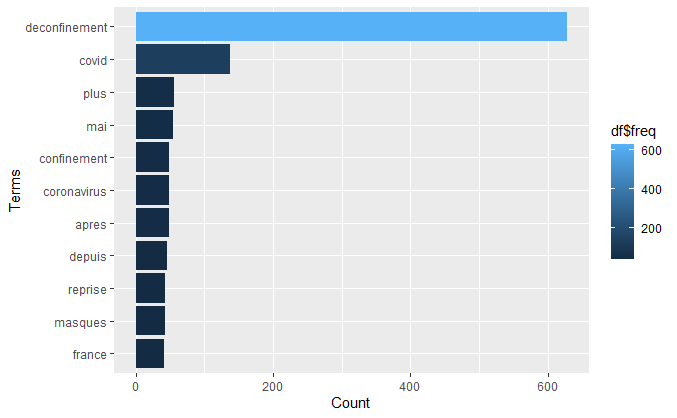

```r
#frequence des mots
mfrequent <- colSums(mdocTerms)
mfrequent <- subset(mfrequent, mfrequent >=40)
df <- data.frame(term = names(mfrequent), freq = mfrequent)

#visualisation des mots fréquents
ggplot(df,aes(x = reorder(df$term, +df$freq), y = freq, fill=df$freq)) + geom_bar(stat = "identity") +
  scale_colour_gradientn(colors = terrain.colors(10)) + xlab("Terms") + ylab("Count") + coord_flip()
```

```r
#termes n'apparaissant qu'une fois
mfrequent2 <- colSums(mdocTerms)
print(length(which(mfrequent2<=2)))
```

```
[1] 2917
```

```r
#ne conserver que les termes apparaissant plus de 2 fois dans la matrice
docTermsClean <- mdocTerms[,colSums(mdocTerms) > 2]
print(dim(docTermsClean))
```

```
[1] 1077  780
```

Finalement, nous avons 780 mots pertinents et nous pouvons ainsi appliquer l’algorithme k-means sur notre matrice document-termes finale.

Algorithme du k-means

Avant d’appliquer l’algorithme du k-means, nous devons choisir le nombre du clusters k, plusiers méthodes existent afin de nous faciliter ce choix:

Méthode de silhouette:

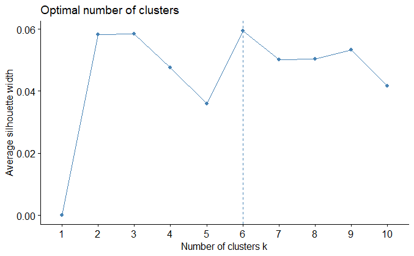

```r
fviz_nbclust(docTermsClean, kmeans, method = "silhouette")
```

La méthode de silhouette nous suggère de choisir 6 clusters.

Méthode Elbow

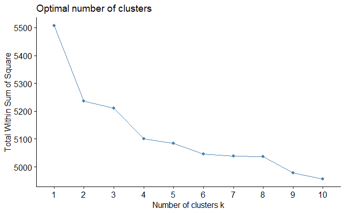

```r
set.seed(123)

fviz_nbclust(docTermsClean, kmeans, method = "wss")
```

D’après le resultat de la méthode Elbow, on peut opter pour 4 clusters.

nous pouvons aussi visualiser les résultats du k-means en essayons différents k:

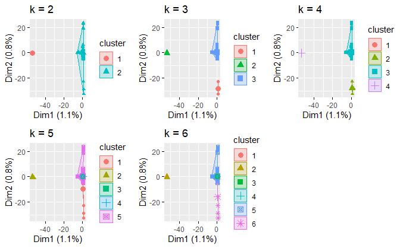

```r
#centrer et réduire les données
#pour éviter que les variables à forte variance pèsent indûment sur les résultats
docTermsClean <- scale(docTermsClean)

#k-means
k2 <- kmeans(docTermsClean, centers = 2, nstart = 25)
k3 <- kmeans(docTermsClean, centers = 3, nstart = 25)
k4 <- kmeans(docTermsClean, centers = 4, nstart = 25)
k5 <- kmeans(docTermsClean, centers = 5, nstart = 25)
k6 <- kmeans(docTermsClean, centers = 6, nstart = 25)


#visualiser et comparer
p1 <- fviz_cluster(k2, geom = "point", data = docTermsClean) + ggtitle("k = 2")
p2 <- fviz_cluster(k3, geom = "point",  data = docTermsClean) + ggtitle("k = 3")
p3 <- fviz_cluster(k4, geom = "point",  data = docTermsClean) + ggtitle("k = 4")
p4 <- fviz_cluster(k5, geom = "point",  data = docTermsClean) + ggtitle("k = 5")
p5 <- fviz_cluster(k6, geom = "point",  data = docTermsClean) + ggtitle("k = 6")

grid.arrange(p1, p2, p3, p4,p5, nrow = 2)
```

D’après les résultats de cette visualisation ainsi que les deux méthodes du choix de k, nous avons décidé d’opter pour k=4.

```r
set.seed(123)
k <- 4
kmeansResults <- kmeans(docTermsClean,k, nstart = 25)
str(kmeansResults)
```

```
List of 9
 $ cluster     : Named int [1:1077] 4 4 4 4 4 4 4 4 4 4 ...
  ..- attr(*, "names")= chr [1:1077] "1" "2" "3" "4" ...
 $ centers     : num [1:4, 1:780] 0.6199 0.8452 0.8452 -0.0125 -0.0683 ...
  ..- attr(*, "dimnames")=List of 2
  .. ..$ : chr [1:4] "1" "2" "3" "4"
  .. ..$ : chr [1:780] "deconfinement" "drone" "pou" "surveillance" ...
 $ totss       : num 839280
 $ withinss    : num [1:4] 8.68e+03 3.80e-29 4.88e+02 8.12e+05
 $ tot.withinss: num 820933
 $ betweenss   : num 18347
 $ size        : int [1:4] 9 3 6 1059
 $ iter        : int 3
 $ ifault      : int 0
 - attr(*, "class")= chr "kmeans"
```

Determinons maintenant les caractéristiques de chaque cluster

```r
for (i in 1:k){
  cat(paste("cluster",i,":",sep=""))
  s <- sort(kmeansResults$centers[i,],decreasing = T)
  cat(names(s)[1:15],"\n")
}
```

```
cluster1:familles accompagnant aesh nationale handicap questions cci reseau education commercants voila eleves ans periode reponses
cluster2:boite jarre pandore vents corse rattraper maison ouverte perdu quatre temps faut deconfinement revient presente
cluster3:legers vehicules delai tolerance technique arrete controle gouvernement juin covid deconfinement revient presente celle celebrations
cluster4:plus mai confinement coronavirus apres depuis reprise masques france retour plages reouverture faire masque paris
```

Classification ascendante hiérarchique

```r
docTermsCleanbis <- mdocTerms[,colSums(mdocTerms) > 2]
set.seed(123)
#supprimer les valeurs manquantes
docTermsCleanbis <- na.omit(docTermsCleanbis)

#centrer et réduire les données
docTermsCleanbis <- scale(docTermsCleanbis)

#matrice de dissimilarité
mdist <- dist(docTermsCleanbis, method = "euclidean")

# Hierarchical clustering using Complete Linkage
hc <- hclust(mdist, method = "ward" )
```

```
The "ward" method has been renamed to "ward.D"; note new "ward.D2"
```

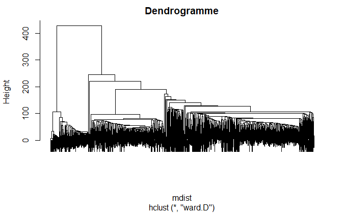

```r
#dendrogramme
plot(hc, labels = FALSE, main = "Dendrogramme")
```

Afin de décider à quel niveau on peut couper l’arbre, nous allons repérer les sauts d’inertie du dendrogramme selon le nombre de classes retenues.

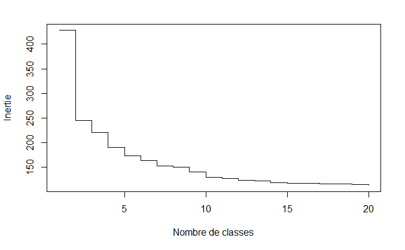

```r
inertie <- sort(fit$height, decreasing = TRUE)
plot(inertie[1:20], type = "s", xlab = "Nombre de classes", ylab = "Inertie")
```

On remaqure 2 sauts assez nets: 2 et 4 classes que nous pouvons representer ci-dessous en vert et en rouge respectivement.

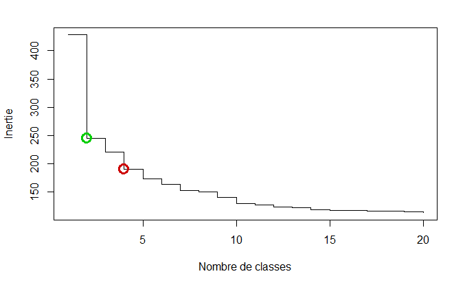

```r
plot(inertie[1:20], type = "s", xlab = "Nombre de classes", ylab = "Inertie")
points(c(2, 4), inertie[c(2, 4)], col = c("green3", "red3"), cex = 2, lwd = 3)
```

Par ailleurs, il existe une autre méthode pour trouver la meileur partition, il s’agit de la fonction “best.cutree” qui permet de calculer cet indicateur à partir de n’importe quel dendrogramme calculé avec hclust ou agnes. (cette fonction est proposée par l’extension JLutils (disponible sur GitHub))

```
[1] 2
```

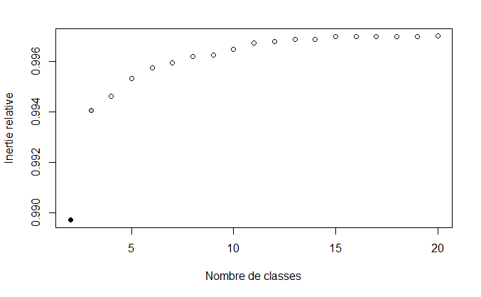

```r
#install_github("larmarange/JLutils")
#best.cutree(hc, min=2)
best.cutree(hc, min=2, graph = TRUE, xlab = "Nombre de classes",
  ylab = "Inertie relative")
```

D’après les sauts repérés et le resultat de la fonction best.cutree, nous optons pour une partition de 2 classes.

```r
set.seed(123)
# couper l'arbre en 2 groupes
sub_grp <- cutree(hc, k = 2)

# nombre de documents dans chaque classe
table(sub_grp)
```

```
sub_grp
  1   2
923 154
```

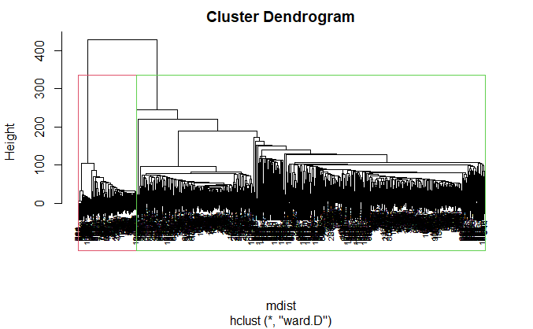

```r
#couper l'arbre en deux classes
plot(hc, cex = 0.6)
rect.hclust(hc, k = 2, border = 2:5)
```

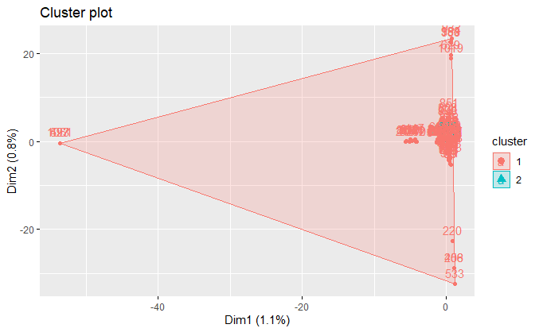

```r
sub_grp <- cutree(hc, k = 2)
fviz_cluster(list(data = docTermsCleanbis, cluster = sub_grp))
```

Analyse catégorielle:

AFC

Dans cette analyse, nous allons garder uniquement les mots les plus fréquents, ceux qui apparaissent plus de 20 fois (vu que nous avons beaucoup de mots).

```r
docTermsCleanAFC <- mdocTerms[,colSums(mdocTerms) > 20]
```

[output not shown]

```
**Results of the Correspondence Analysis (CA)**
The row variable has  924  categories; the column variable has 32 categories
The chi square of independence between the two variables is equal to 25286.38 (p-value =  1 ).
*The results are available in the following objects:

   name              description
1  "$eig"            "eigenvalues"
2  "$col"            "results for the columns"
3  "$col$coord"      "coord. for the columns"
4  "$col$cos2"       "cos2 for the columns"
5  "$col$contrib"    "contributions of the columns"
6  "$row"            "results for the rows"
7  "$row$coord"      "coord. for the rows"
8  "$row$cos2"       "cos2 for the rows"
9  "$row$contrib"    "contributions of the rows"
10 "$call"           "summary called parameters"
11 "$call$marge.col" "weights of the columns"
12 "$call$marge.row" "weights of the rows"
```

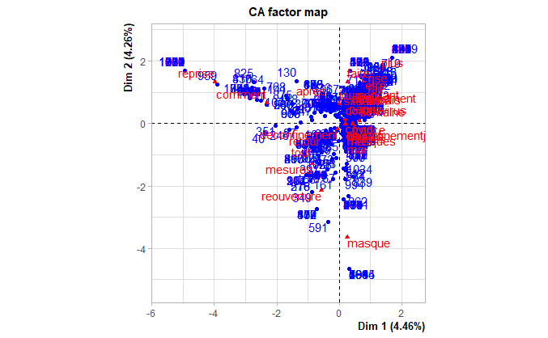

```r
#calculer l'AFC
CA (docTermsCleanAFC, ncp = 5, graph = TRUE)
```

```r
res.ca <- CA (docTermsCleanAFC, graph = FALSE)
```

[output not shown]

```r
print(res.ca)
```

```
**Results of the Correspondence Analysis (CA)**
The row variable has  924  categories; the column variable has 32 categories
The chi square of independence between the two variables is equal to 25286.38 (p-value =  1 ).
*The results are available in the following objects:

   name              description
1  "$eig"            "eigenvalues"
2  "$col"            "results for the columns"
3  "$col$coord"      "coord. for the columns"
4  "$col$cos2"       "cos2 for the columns"
5  "$col$contrib"    "contributions of the columns"
6  "$row"            "results for the rows"
7  "$row$coord"      "coord. for the rows"
8  "$row$cos2"       "cos2 for the rows"
9  "$row$contrib"    "contributions of the rows"
10 "$call"           "summary called parameters"
11 "$call$marge.col" "weights of the columns"
12 "$call$marge.row" "weights of the rows"
```

Visualisation et interprétation

Nous allons nous intéresser aux colonnes (les mots)

```r
#extraire les résultats pour les colonnes
col <- get_ca_col(res.ca)
col
```

```
Correspondence Analysis - Results for columns
 ===================================================
  Name       Description
1 "$coord"   "Coordinates for the columns"
2 "$cos2"    "Cos2 for the columns"
3 "$contrib" "contributions of the columns"
4 "$inertia" "Inertia of the columns"
```

Accéder aux différents composants

```r
#accéder aux différents composants
# Coordonnées
head(col$coord)
```

```
                       Dim 1        Dim 2        Dim 3        Dim 4       Dim 5
deconfinement     -0.0551069 -0.173108794  0.004233859 -0.038937446 -0.06384877
plages             0.3601146 -0.315000903  0.230345366  0.002653223 -1.21289751
plus               1.3500096  1.652412770  0.155639746 -0.316370995 -2.14627433
covid              0.1948705 -0.006027514 -0.155834466  0.263517744  0.16188222
deconfinementjour  0.2169116 -0.206157213 -0.305118755 -0.816107856  0.52258159
crise              0.7170991  1.180583536  0.787865038  2.127367310  1.19431275
```

```r
# Qualité de représentation
head(col$cos2)
```

```
                        Dim 1        Dim 2        Dim 3        Dim 4       Dim 5
deconfinement     0.004163167 4.108186e-02 2.457449e-05 2.078485e-03 0.005588779
plages            0.005972221 4.569599e-03 2.443506e-03 3.241919e-07 0.067748965
plus              0.107522712 1.610881e-01 1.429116e-03 5.904999e-03 0.271767141
covid             0.008234874 7.878459e-06 5.266134e-03 1.505860e-02 0.005682810
deconfinementjour 0.001707045 1.541972e-03 3.377670e-03 2.416432e-02 0.009908038
crise             0.015401984 4.174570e-02 1.859182e-02 1.355512e-01 0.042722286
```

```r
# Contributions
head(col$contrib)
```

```
                      Dim 1        Dim 2       Dim 3        Dim 4      Dim 5
deconfinement     0.1689259  1.746666698 0.001056391 9.036702e-02  0.2487884
plages            0.4020445  0.322332262 0.174268654 2.338466e-05  5.0035892
plus              9.0403739 14.191792249 0.127297925 5.319818e-01 25.0682421
covid             0.4608264  0.000461965 0.312205014 9.029334e-01  0.3488866
deconfinementjour 0.1083586  0.102561072 0.227145128 1.643554e+00  0.6899966
crise             1.1842852  3.363403142 1.514500001 1.116796e+01  3.6039178
```

```r
print(col$coord)
```

```
                         Dim 1        Dim 2        Dim 3        Dim 4       Dim 5
deconfinement     -0.055106901 -0.173108794  0.004233859 -0.038937446 -0.06384877
plages             0.360114598 -0.315000903  0.230345366  0.002653223 -1.21289751
plus               1.350009619  1.652412770  0.155639746 -0.316370995 -2.14627433
covid              0.194870477 -0.006027514 -0.155834466  0.263517744  0.16188222
deconfinementjour  0.216911571 -0.206157213 -0.305118755 -0.816107856  0.52258159
crise              0.717099070  1.180583536  0.787865038  2.127367310  1.19431275
coronavirus        0.191994714  0.134973257 -0.484277680 -0.029330549 -0.05637884
respect            0.406966438  0.513870031  0.004713655 -0.019556201 -1.51346722
reprise           -3.976802933  1.318928474 -1.004846380 -0.123101244 -0.24703467
confinement        0.405609708  0.520838649 -0.293589978  0.844244991  0.25081796
jour               0.672530910  0.189595449  0.054294525 -1.041568374 -0.33837284
etre               0.837309494  0.927529240 -0.094172757 -0.558448471  1.01279346
fait               0.900841488  0.837508411 -0.156248568  0.984192438  2.99942109
apres             -0.406035136  0.748625997 -0.633749202  0.795321037 -0.13183492
jours              0.004058679  0.618788463 -0.486088847  1.205166765  0.29097399
masques            0.235305062 -0.379869890 -0.783197232  0.187862425  0.57371015
france             0.428586830 -0.007239048 -0.970116175  0.270160299 -0.95199200
pendant            0.562500029  0.637667323 -0.106556012  1.469526510  0.57697151
situation          0.126804339  0.439100557 -0.459910761  0.117855797  0.90764437
reouverture       -0.570518045 -2.139287858  2.757611767  0.443937977 -1.05876199
depuis             0.284396254 -0.237366194 -0.039146515 -0.442179833  0.38074564
mai                0.235515814 -0.651247921  0.406145151 -0.753249926  0.15580625
mesures           -0.852592095 -1.291893410  0.434246480  0.277961552 -0.40164586
tout              -0.912157432 -0.748303918  2.890390696  1.522236464  0.25397147
faire              0.272586053  1.321700142  0.894839260 -3.467025209  2.07778909
retour            -0.625879406 -0.388973246  1.574600437 -1.342164389  0.23606283
francais           0.621109360  0.482315008 -0.289403778 -0.264631335 -0.55700366
tous               0.261359459 -0.200228836  1.225426124  1.674886398  1.50209627
semaine            0.640913326  0.083897358  0.180427173 -1.611084533 -0.26510184
paris              0.305146813  0.187282927 -0.315680002  0.442689188 -0.90855810
comment           -2.313595479  0.659595020  0.028444760 -0.236426442 -0.00122382
masque             0.260177414 -3.654512583 -3.127675220 -0.422153437  0.48179846
```

Graphiques: qualité et contribution

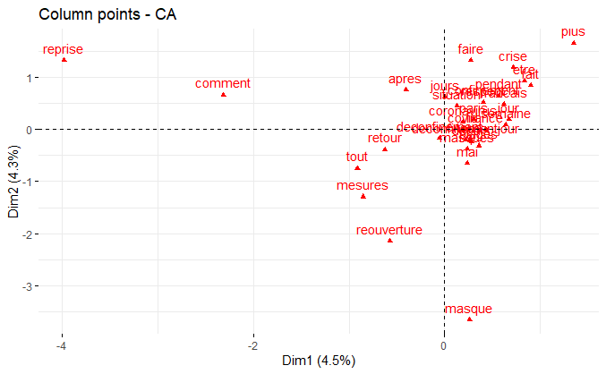

```r
#graphique des colonnes
fviz_ca_col (res.ca)
```

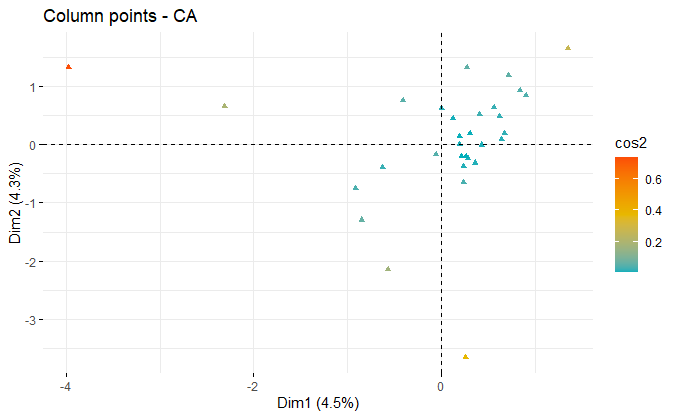

```r
#Les points colonnes en fonction de leurs cos2
fviz_ca_col (res.ca, col.col = "cos2",
             gradient.cols = c("#00AFBB", "#E7B800", "#FC4E07"),
             repel = TRUE)
```

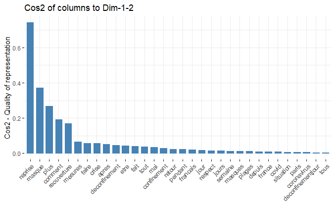

```r
#bar plot du cos2 des colonnes
fviz_cos2 (res.ca, choice = "col", axes = 1:2)
```

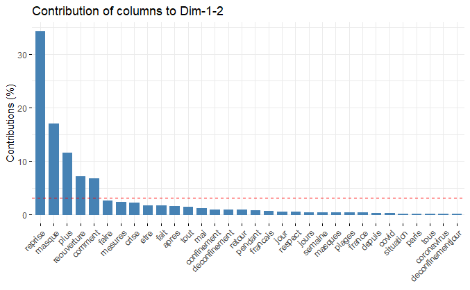

```r
#la contribution des colonnes aux deux premières dimensions
fviz_contrib (res.ca, choice = "col", axes = 1:2)
```